# Eurovision Dataset Analysis

2022-05-17

# TidyTuesday

Join the R4DS Online Learning Community in the weekly #TidyTuesday event! Every week we post a raw dataset, a chart or article related to that dataset, and ask you to explore the data. While the dataset will be “tamed”, it will not always be tidy! As such you might need to apply various R for Data Science techniques to wrangle the data into a true tidy format. The goal of TidyTuesday is to apply your R skills, get feedback, explore other’s work, and connect with the greater #RStats community! As such we encourage everyone of all skills to participate!

# Load the weekly Data

Download the weekly data and make available in the `tt` object.

```r
tt <- tt_load("2022-05-17")
```

```
## --- Compiling #TidyTuesday Information for 2022-05-17 ----
```

```
## --- There are 2 files available ---
```

```
## --- Starting Download ---
```

```
## --- Download complete ---
```

# Readme

Take a look at the readme for the weekly data to get insight on the dataset. This includes a data dictionary, source, and a link to an article on the data.

```r
tt
```

# Glimpse Data

Take an initial look at the format of the data available.

```r
tt %>%
  map(glimpse);
```

```
## Rows: 2,005
## Columns: 18
## $ event          <chr> "Turin 2022", "Turin 2022", "Turin 2022", "Turin 2022",…
## $ host_city      <chr> "Turin", "Turin", "Turin", "Turin", "Turin", "Turin", "…
## $ year           <dbl> 2022, 2022, 2022, 2022, 2022, 2022, 2022, 2022, 2022, 2…
## $ host_country   <chr> "Italy", "Italy", "Italy", "Italy", "Italy", "Italy", "…
## $ event_url      <chr> "https://eurovision.tv/event/turin-2022", "https://euro…
## $ section        <chr> "first-semi-final", "first-semi-final", "first-semi-fin…
## $ artist         <chr> "Kalush Orchestra", "S10", "Amanda Georgiadi Tenfjord",…
## $ song           <chr> "Stefania", "De Diepte", "Die Together", "Saudade, Saud…
## $ artist_url     <chr> "https://eurovision.tv/participant/kalush-orchestra-22"…
## $ image_url      <chr> "https://static.eurovision.tv/hb-cgi/images/963164d0-06…
## $ artist_country <chr> "Ukraine", "Netherlands", "Greece", "Portugal", "Bulgar…
## $ country_emoji  <chr> ":flag_ua:", ":flag_nl:", ":flag_gr:", ":flag_pt:", ":f…
## $ running_order  <dbl> 6, 8, 15, 10, 7, 5, 17, 16, 3, 9, 4, 14, 11, 1, 12, 2, …
## $ total_points   <dbl> 337, 221, 211, 208, 29, 15, 187, 177, 159, 154, 118, 10…
## $ rank           <dbl> 1, 2, 3, 4, 16, 17, 5, 6, 7, 8, 9, 10, 11, 12, 13, 14, …
## $ rank_ordinal   <chr> "1st", "2nd", "3rd", "4th", "16th", "17th", "5th", "6th…
## $ qualified      <lgl> TRUE, TRUE, TRUE, TRUE, FALSE, FALSE, TRUE, TRUE, TRUE,…
## $ winner         <lgl> FALSE, FALSE, FALSE, FALSE, FALSE, FALSE, FALSE, FALSE,…
## Rows: 56,312
## Columns: 8
## $ year               <dbl> 1975, 1975, 1975, 1975, 1975, 1975, 1975, 1975, 197…
## $ semi_final         <chr> "f", "f", "f", "f", "f", "f", "f", "f", "f", "f", "…
## $ edition            <chr> "1975f", "1975f", "1975f", "1975f", "1975f", "1975f…
## $ jury_or_televoting <chr> "J", "J", "J", "J", "J", "J", "J", "J", "J", "J", "…
## $ from_country       <chr> "Belgium", "Belgium", "Belgium", "Belgium", "Belgiu…
## $ to_country         <chr> "Belgium", "Finland", "France", "Germany", "Ireland…
## $ points             <dbl> 0, 0, 2, 0, 12, 1, 6, 0, 7, 0, 0, 0, 4, 0, 8, 3, 0,…
## $ duplicate          <chr> "x", NA, NA, NA, NA, NA, NA, NA, NA, NA, NA, NA, NA…
```

```
## $eurovision
## # A tibble: 2,005 × 18
##    event  host_city  year host_country event_url section artist song  artist_url
##    <chr>  <chr>     <dbl> <chr>        <chr>     <chr>   <chr>  <chr> <chr>
##  1 Turin… Turin      2022 Italy        https://… first-… Kalus… Stef… https://e…
##  2 Turin… Turin      2022 Italy        https://… first-… S10    De D… https://e…
##  3 Turin… Turin      2022 Italy        https://… first-… Amand… Die … https://e…
##  4 Turin… Turin      2022 Italy        https://… first-… MARO   Saud… https://e…
##  5 Turin… Turin      2022 Italy        https://… first-… Intel… Inte… https://e…
##  6 Turin… Turin      2022 Italy        https://… first-… LPS    Disko https://e…
##  7 Turin… Turin      2022 Italy        https://… first-… Rosa … Snap  https://e…
##  8 Turin… Turin      2022 Italy        https://… first-… Subwo… Give… https://e…
##  9 Turin… Turin      2022 Italy        https://… first-… Monik… Sent… https://e…
## 10 Turin… Turin      2022 Italy        https://… first-… Zdob … Tren… https://e…
## # … with 1,995 more rows, and 9 more variables: image_url <chr>,
## #   artist_country <chr>, country_emoji <chr>, running_order <dbl>,
## #   total_points <dbl>, rank <dbl>, rank_ordinal <chr>, qualified <lgl>,
## #   winner <lgl>
##
## $`eurovision-votes`
## # A tibble: 56,312 × 8
##     year semi_final edition jury_or_televoting from_country to_country points
##    <dbl> <chr>      <chr>   <chr>              <chr>        <chr>       <dbl>
##  1  1975 f          1975f   J                  Belgium      Belgium         0
##  2  1975 f          1975f   J                  Belgium      Finland         0
##  3  1975 f          1975f   J                  Belgium      France          2
##  4  1975 f          1975f   J                  Belgium      Germany         0
##  5  1975 f          1975f   J                  Belgium      Ireland        12
##  6  1975 f          1975f   J                  Belgium      Israel          1
##  7  1975 f          1975f   J                  Belgium      Italy           6
##  8  1975 f          1975f   J                  Belgium      Luxembourg      0
##  9  1975 f          1975f   J                  Belgium      Malta           7
## 10  1975 f          1975f   J                  Belgium      Monaco          0
## # … with 56,302 more rows, and 1 more variable: duplicate <chr>
```

# Wrangle and Visualize

```r
eurovision <- tt$eurovision
votes <- tt$"eurovision-votes"
```

What is the trend of number of songs submitted per year?

```r
# colorspace::choose_color()
colors <- c('#629F55', '#6394C9', '#CD7792')

eurovision_year <- eurovision %>%
  group_by(year, artist_country) %>%
  mutate(song_count = n()) %>%
  ungroup() %>%
  group_by(year) %>%
  summarize(songs_count = n(),
            country_count = n_distinct(artist_country),
            artist_count = n_distinct(artist)) %>%
  pivot_longer(cols = c(songs_count, country_count, artist_count), names_to = "count_type", values_to = "count")

eurovision_year
```

```
## # A tibble: 201 × 3
##     year count_type    count
##    <dbl> <chr>         <int>
##  1  1956 songs_count      14
##  2  1956 country_count     7
##  3  1956 artist_count     12
##  4  1957 songs_count      10
##  5  1957 country_count    10
##  6  1957 artist_count     10
##  7  1958 songs_count      10
##  8  1958 country_count    10
##  9  1958 artist_count     10
## 10  1959 songs_count      11
## # … with 191 more rows
```

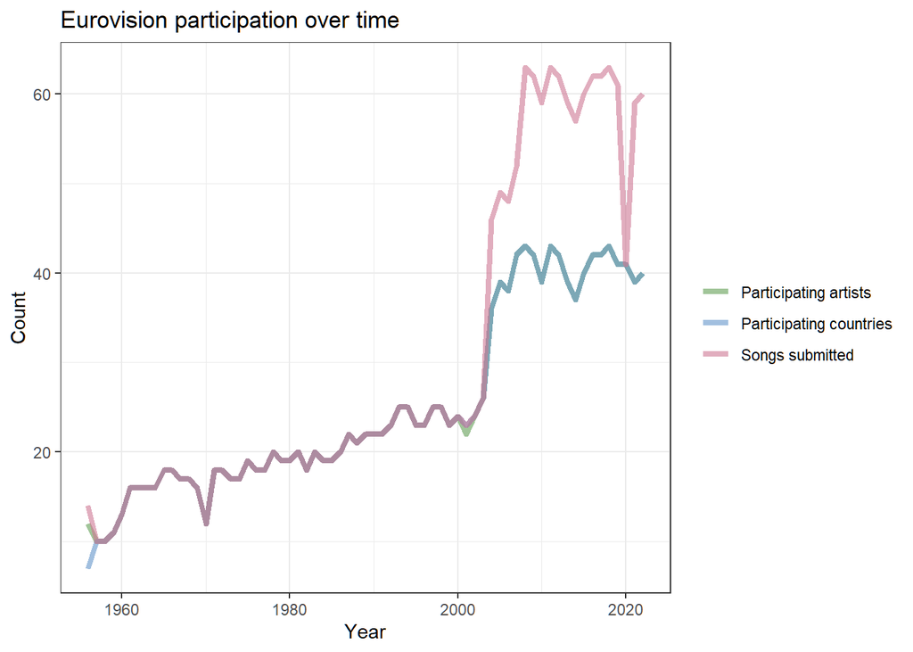

```r
eurovision_year %>%
  ggplot() +
  geom_line(size = 1.5, alpha = 0.6) +
  aes(x = year, y = count, color = count_type) +
  theme_bw() +
  scale_x_continuous(name = "Year") +
  scale_y_continuous(name = "Count") +
  scale_color_manual(values = colors, name = NULL, labels = c("Participating artists", "Participating countries", "Songs submitted")) +
  ggtitle("Eurovision participation over time")
```

```r
eurovision %>%
  group_by()
```

```
## # A tibble: 2,005 × 18
##    event  host_city  year host_country event_url section artist song  artist_url
##    <chr>  <chr>     <dbl> <chr>        <chr>     <chr>   <chr>  <chr> <chr>
##  1 Turin… Turin      2022 Italy        https://… first-… Kalus… Stef… https://e…
##  2 Turin… Turin      2022 Italy        https://… first-… S10    De D… https://e…
##  3 Turin… Turin      2022 Italy        https://… first-… Amand… Die … https://e…
##  4 Turin… Turin      2022 Italy        https://… first-… MARO   Saud… https://e…
##  5 Turin… Turin      2022 Italy        https://… first-… Intel… Inte… https://e…
##  6 Turin… Turin      2022 Italy        https://… first-… LPS    Disko https://e…
##  7 Turin… Turin      2022 Italy        https://… first-… Rosa … Snap  https://e…
##  8 Turin… Turin      2022 Italy        https://… first-… Subwo… Give… https://e…
##  9 Turin… Turin      2022 Italy        https://… first-… Monik… Sent… https://e…
## 10 Turin… Turin      2022 Italy        https://… first-… Zdob … Tren… https://e…
## # … with 1,995 more rows, and 9 more variables: image_url <chr>,
## #   artist_country <chr>, country_emoji <chr>, running_order <dbl>,
## #   total_points <dbl>, rank <dbl>, rank_ordinal <chr>, qualified <lgl>,
## #   winner <lgl>
```

```r
eurovision %>%
  group_by(artist_country) %>%
  summarize(n = n())
```

```
## # A tibble: 52 × 2
##    artist_country           n
##    <chr>                <int>
##  1 Albania                 28
##  2 Andorra                  6
##  3 Armenia                 25
##  4 Australia               13
##  5 Austria                 60
##  6 Azerbaijan              27
##  7 Belarus                 23
##  8 Belgium                 72
##  9 Bosnia & Herzegovina    26
## 10 Bulgaria                20
## # … with 42 more rows
```

How often did countries participate in Eurovision and how did they perform?

```r
# map the host countries

library(rnaturalearth)
library(rnaturalearthdata)
library(sf)
library(ggiraph)
```

```r
map_countries <- ne_countries(scale = "medium", continent = c("asia", "europe"), returnclass = "sf")


hostcountry_eurovision <- eurovision %>%
  group_by(host_country) %>%
  summarize(n_hosted = n_distinct(year))

artistcountry_eurovision <-
  eurovision %>%
  group_by(artist_country) %>%
  mutate(n_year = n_distinct(year)) %>%
  ungroup() %>%
  group_by(artist_country, section) %>%
  summarize(first = sum(rank == 1, na.rm = TRUE),
            second = sum(rank == 2, na.rm = TRUE),
            third = sum(rank == 3, na.rm = TRUE),
            grand_champion = sum(winner),
            n_participated = n(),
            n_year = first(n_year)) %>%
  ungroup() %>%
  group_by(artist_country) %>%
  summarize(n_participated = sum(n_participated),
            first = sum(first),
            second = sum(second),
            third = sum(third),
            grand_champion = sum(grand_champion),
            n_year_participated = first(n_year)) %>%
  mutate(top3 = first + second + third,
         percent_top3 = top3/n_participated)
eurovision_summary <- hostcountry_eurovision %>%
  full_join(artistcountry_eurovision, by = c("host_country" = "artist_country")) %>%
  rename(country = host_country) %>%
  mutate(n_hosted = replace_na(n_hosted, 0))

# eurovision_summary %>% View()


map_eurovision <- eurovision_summary %>%
  right_join(map_countries %>% select(admin, geometry), by = c("country" = "admin")) %>%
  filter(!country %in% c("Antarctica")) %>%
  st_as_sf(sf_column_name = c("geometry")) %>%
  mutate(
         tooltip = case_when(
           !is.na(n_participated) ~ paste0(country, "\n",
                                           "Participated: ", n_participated, "\n",
                                           "Years: ", n_year_participated, "\n",
                                           "Hosted: ", n_hosted, "\n",
                                           "First: ", first, "\n",
                                           "Second: ", third, "\n",
                                           "Third: ", second, "\n",
                                           "Podium % (Top 3): ", signif(percent_top3, 3)*100, "%"
                                           ),
           TRUE ~ paste0(country, ": Non Participant")
           ),
         n_participated = replace_na(n_participated, 0)
  )
```

Interactive map:

```r
map_eurovision_interactive <- map_eurovision %>%
  ggplot() +
  geom_sf_interactive() +
  aes(fill = n_participated,
      tooltip = tooltip,
      data_id = tooltip) +
  coord_sf(xlim = c(-40, 180), ylim = c(30, 90), expand = FALSE) +
  scale_fill_continuous_sequential(palette = "Blues", name = "Times Participated") +
  ggtitle("Eurovision Participation",
          subtitle = "Interactive Map")

girafe(
  ggobj = map_eurovision_interactive,
  width_svg = 9, height_svg = 9*0.618,
  options = list(
    opts_tooltip(css = "background: #F5F5F5; color: #191970")
    ))
```

[interactive chart not shown]

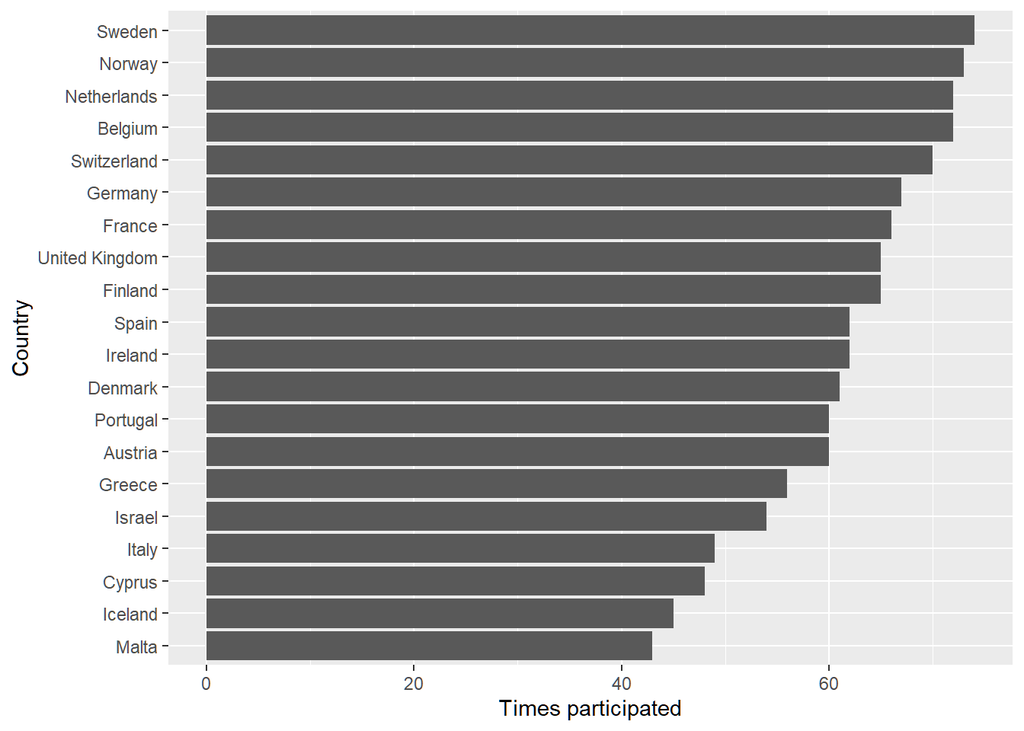

```r
eurovision_summary %>%
  mutate(country = fct_reorder(country, n_participated)) %>%
  top_n(20, n_participated) %>%
  ggplot() + geom_col() +
  aes(x = n_participated, y = country) +
  xlab("Times participated") +
  ylab("Country")
```

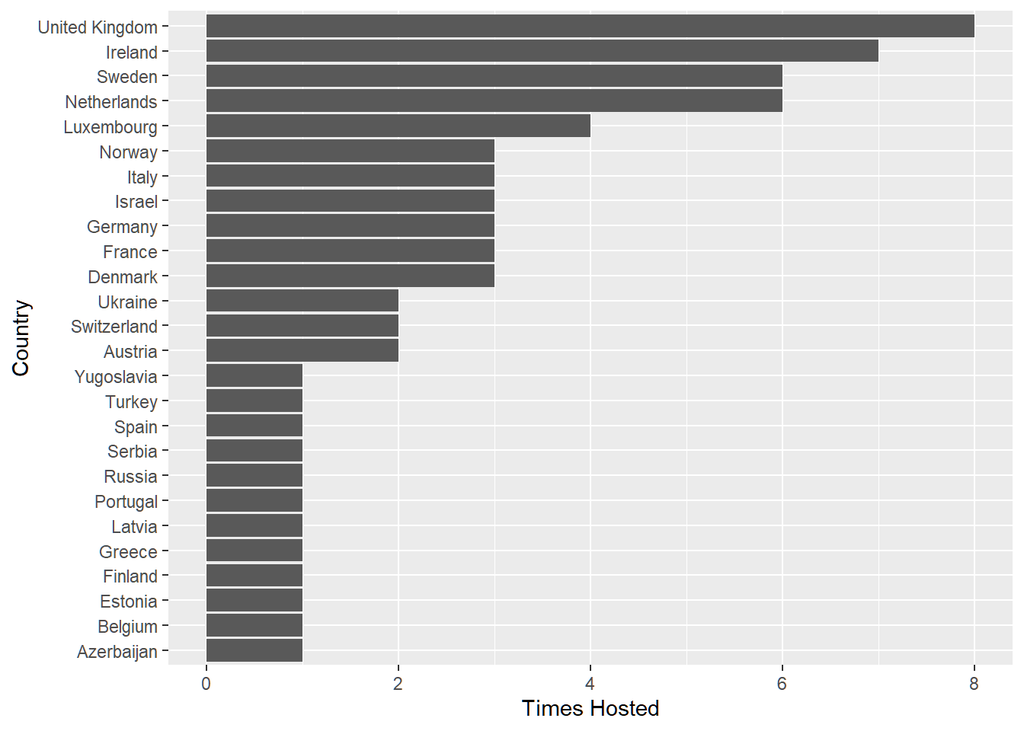

```r
eurovision_summary %>%
  mutate(country = fct_reorder(country, n_hosted)) %>%
  top_n(20, n_hosted) %>%
  ggplot() + geom_col() +
  aes(x = n_hosted, y = country) +
  xlab("Times Hosted") +
  ylab("Country")
```

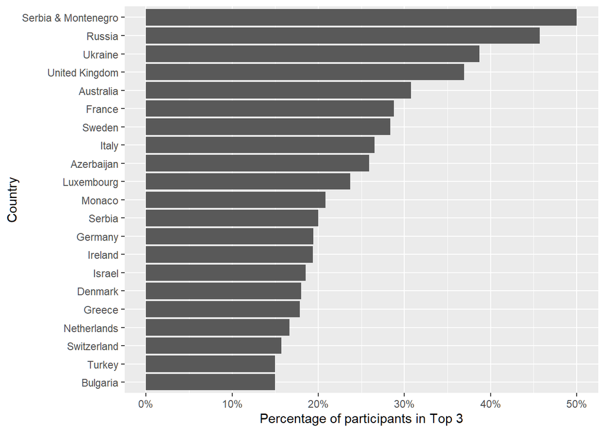

```r
eurovision_summary %>%
  mutate(country = fct_reorder(country, percent_top3)) %>%
  top_n(20, percent_top3) %>%
  ggplot() + geom_col() +
  aes(x = percent_top3, y = country) +
  xlab("Percentage of participants in Top 3") +
  ylab("Country") +
  scale_x_continuous(labels = scales::percent)
```